# Unit 1 Getting to know the data作業總評

2021/10/06

## 單元1學習重點

單元1是認識這個學期用於作業演練的真實研究資料，Woodworth等人(2017)的公開資料檔案是單元3到單元8的演練資料，我們將學習始何使用R語言清理整頓及視覺化心理學研究的原始資料。練習1與練習3的問題讓同學們初窺原始資料結構，可說是接下來學習R語言程式設計的前菜。因此本次作業著重於建立同學整理檔案的觀念與操作習慣，還有熟悉有效的作業格式及按時上傳作業的習慣。

## 檔案管理範例

初次作業進行過程，教練透過github與同學溝通作業問題，其中有兩位同學的管理方式值得大家效法，在此引用同學的截圖說明建議的檔案管理方式：

- 蔡宜蓁同學

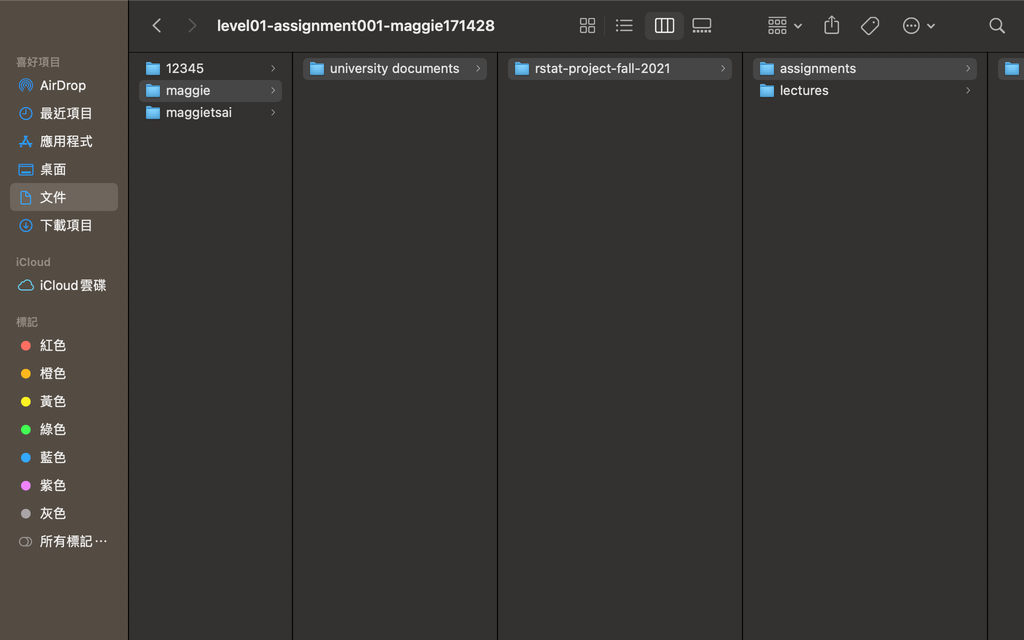

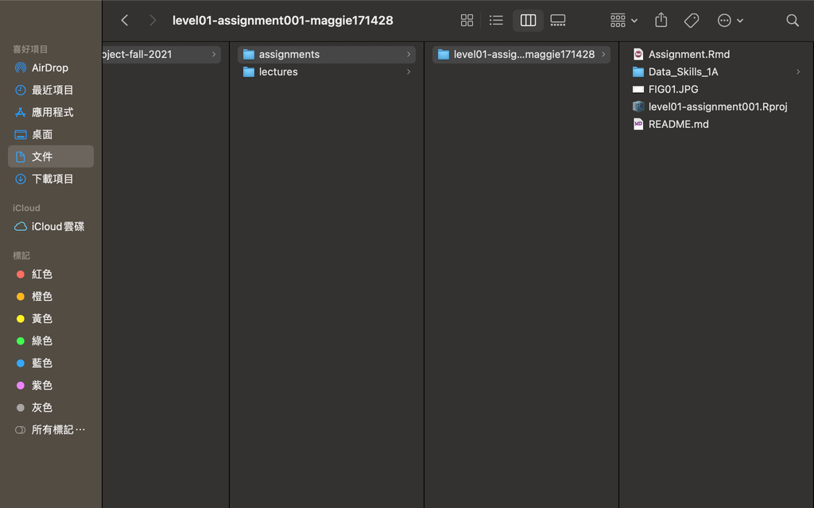

- 蔡少涵

[figure not shown]

兩位同學都有為這門課程設定專屬資料夾，並依階層整理“作業”以及“各單元作業”。本次作業要取得“演練充分度”(OC)最高評分，截圖必須證明個人的資料夾階層設定有達到兩位同學的水準。教練給兩位同學的建議是在“作業”的相同階層設定一個“資料”資料夾，用來存放Woodworth等人(2017)的公開資料檔案。同時要提醒使用**Windows作業系統**的朋友，資料夾名稱最好取英文，以免有些R函式無法辨識。

## 作業繳交狀況

由於部分同學還需要適應操作，第一次作業開放9/30午夜之前，在[討論區單元帖](https://github.com/Rstat-project/ug1-practical/discussions/5)回覆說明未能即時繳交作業的原因，並完成單元1作業補繳，“演練充分度”可得最低評分1分。

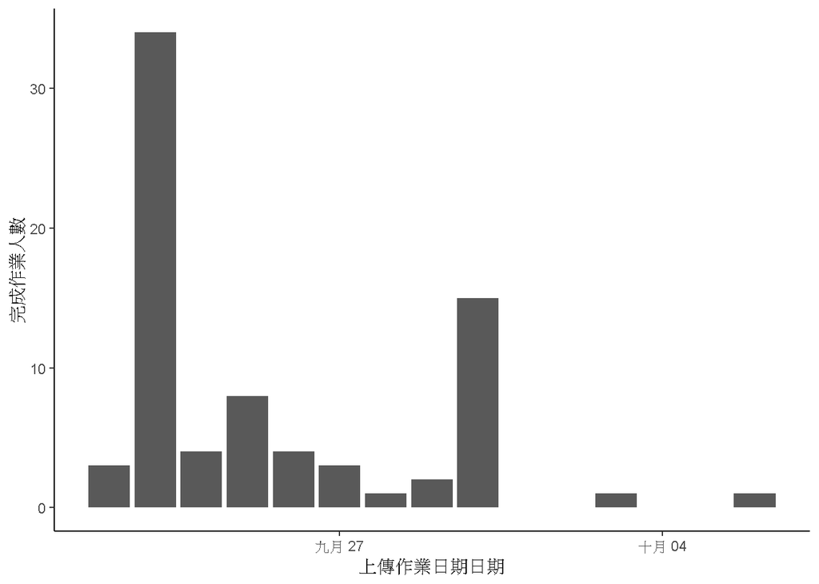

完成日期是9/27或更早之前的同學，“準時推送”(OT)會得到最高評分4分。考慮這是第一次正式作業，未即時上傳作業的同學“準時推送”得到次高評分3分；有領取作業但未繳交作業成果的同學，這次有最低分1分。

## 檔案管理狀況建議

4:有html檔,練習1,3有填寫答案;練習2截圖有呈現作業資料路徑  
3:有html檔,練習1,3有填寫答案;只有呈現演練資料或作業repo的資料夾  
2:有html檔,練習1,3有填寫答案;沒有呈現演練資料或作業repo的資料夾  
1:沒有上傳html，但是Rmd練習1,3有填寫答案  
0:Rmd 沒有填寫任何答案

**註1**：本學期所有單元的作業必須以“Assignment.html” 檔名繳交，才能通過“準時推送”程式碼的判定。如果未製造“Assignment.html”或改成其他檔名，將無法被正確判定。

**註2**: 第三週上課前，在[討論區](https://github.com/Rstat-project/ug1-practical/discussions)的發言或回覆，被教練用emoji標記者，將計入“演練活用度”(EO)評分。本次作業總評分以最高級分登錄。

**註3**: 正式修課人數確定後，在上課時間內完成領取及推送演練成果的動作，將做為點名程序。

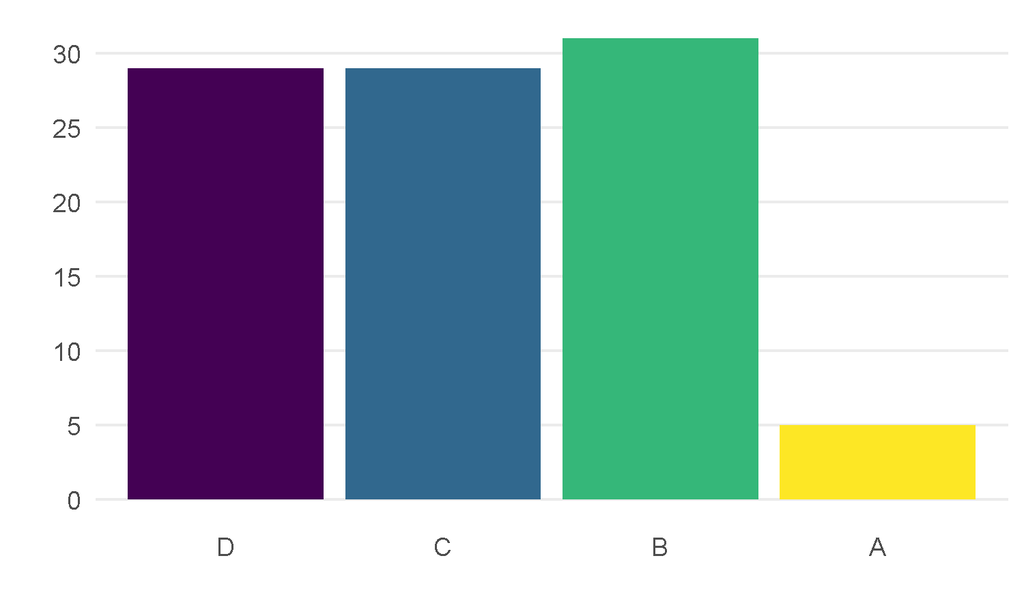

## 檢視個人回饋單

有收到個人評語的同學，只要將個人作業再拉回(git pull)個人的本機端Rstudio，以瀏覽器開啟feedback.html，就能看到教練和組教給的評語。